# 8: Full SEM

Rushabh Barbhaya

2021-01-24

## Full SEM Class Assignment

- We are going to create a model of the following variables:
  - University composite (formative):
    - Class - perception of the way school work, classes, grades, and other related academic goals are going for a student.
    - Social - perception of social networks, friendships, support systems, and connectedness on campus.
    - Learning - perception of student’s happiness with the learning environment on campus (professors, academic support, fit with major, etc.).
  - Psychological factor (reflexive):
    - Depression
    - Anxiety
    - Stress
  - Health factor (reflexive):
    - Chronic health issues
    - Physical fitness and active health
    - Sexual health
- The university composite should predict both the psychological and health factors. We expect that as university perception changes, changes in mental and physical health symptoms should exist as well. Note: all variables have been scaled so that high scores are negative indicators.

## The Data

- Here is the data as a covariance matrix:

```r
library(lavaan)
university.cov <- lav_matrix_lower2full(
    c(169.00,
      73.710, 182.2500,
      73.229, 88.4250, 171.6100,
      63.375, 72.5625, 127.7250, 156.2500,
      42.120, 67.4325, 122.0265, 123.1875, 182.2500,
      57.226, 63.2610, 117.1926, 154.4250, 138.0240, 201.6400,
      30.875, 32.0625, 60.9805, 62.9375, 76.9500, 79.5910, 90.2500,
      36.075, 38.9610, 61.0722, 58.2750, 65.9340, 70.9290, 81.1965, 123.2100,
      18.096, 21.1410, 26.2131, 39.1500, 44.6310, 46.9452, 48.7635, 56.0106, 75.6900))

rownames(university.cov) <-
    colnames(university.cov) <-
    c("class", "social", "learn", "chronic", "physical", "sex",
      "depression", "anxiety", "stress")
```

## Build the Model

- In this section, build the full structural model with the composite indicator.

```r
model = '
uni <~ class + social + learn
psych =~ depression + anxiety + stress
health =~ chronic + physical + sex
uni =~ psych + health
'
```

## Analyze the Model

- Analyze the model with the `sem()` function. There are 300 participants in the dataset.

```r
model.fit = sem(model, sample.cov = university.cov, sample.nobs = 300)
```

Because University is predicting only Psychology and Health, we have two regression paths that act like a small measurement model for University. The identification for this section is not met, so we need to set them equal to each other or create a marker variable to control for these paths. The easiest solution is to set `University =~ Psychology + Health` rather than set two separate regressions. Rerun your `composite.fit` to make sure you do not get an error.

```r
composite.model <- '
University <~ class + social + learn
Health =~ chronic + physical + sex
Psychology =~ depression + anxiety + stress
University =~ Psychology + Health
'
```

```r
composite.model.fit = sem(composite.model, sample.cov = university.cov, sample.nobs = 300)
```

## Summarize the Model

- Include a summary of the model with standardized loadings, fit measures, and r-square values.

```r
summary(model.fit, standardized = T, rsquare = T, fit.measures = T)
```

```
## lavaan 0.6-7 ended normally after 148 iterations
##
##   Estimator                                         ML
##   Optimization method                           NLMINB
##   Number of free parameters                         16
##
##   Number of observations                           300
##
## Model Test User Model:
##
##   Test statistic                               180.313
##   Degrees of freedom                                23
##   P-value (Chi-square)                           0.000
##
## Model Test Baseline Model:
##
##   Test statistic                              1618.833
##   Degrees of freedom                                33
##   P-value                                        0.000
##
## User Model versus Baseline Model:
##
##   Comparative Fit Index (CFI)                    0.901
##   Tucker-Lewis Index (TLI)                       0.858
##
## Loglikelihood and Information Criteria:
##
##   Loglikelihood user model (H0)              -6212.791
##   Loglikelihood unrestricted model (H1)      -6122.634
##
##   Akaike (AIC)                               12457.581
##   Bayesian (BIC)                             12516.842
##   Sample-size adjusted Bayesian (BIC)        12466.099
##
## Root Mean Square Error of Approximation:
##
##   RMSEA                                          0.151
##   90 Percent confidence interval - lower         0.131
##   90 Percent confidence interval - upper         0.172
##   P-value RMSEA <= 0.05                          0.000
```

[output cut: 39 more lines]

```
##    .sex              43.084    4.628    9.310    0.000   43.084    0.214
##     uni               0.000                               0.000    0.000
##    .psych            55.189    6.165    8.952    0.000    0.738    0.738
##    .health           55.097    5.424   10.158    0.000    0.370    0.370
##
## R-Square:
##                    Estimate
##     depression        0.831
##     anxiety           0.722
##     stress            0.423
##     chronic           0.956
##     physical          0.582
##     sex               0.786
##     psych             0.262
##     health            0.630
```

```r
summary(composite.model.fit, standardized = T, rsquare = T, fit.measure = T)
```

```
## lavaan 0.6-7 ended normally after 148 iterations
##
##   Estimator                                         ML
##   Optimization method                           NLMINB
##   Number of free parameters                         16
##
##   Number of observations                           300
##
## Model Test User Model:
##
##   Test statistic                               180.313
##   Degrees of freedom                                23
##   P-value (Chi-square)                           0.000
##
## Model Test Baseline Model:
##
##   Test statistic                              1618.833
##   Degrees of freedom                                33
##   P-value                                        0.000
##
## User Model versus Baseline Model:
##
##   Comparative Fit Index (CFI)                    0.901
##   Tucker-Lewis Index (TLI)                       0.858
##
## Loglikelihood and Information Criteria:
##
##   Loglikelihood user model (H0)              -6212.791
##   Loglikelihood unrestricted model (H1)      -6122.634
##
##   Akaike (AIC)                               12457.581
##   Bayesian (BIC)                             12516.842
##   Sample-size adjusted Bayesian (BIC)        12466.099
##
## Root Mean Square Error of Approximation:
##
##   RMSEA                                          0.151
##   90 Percent confidence interval - lower         0.131
##   90 Percent confidence interval - upper         0.172
##   P-value RMSEA <= 0.05                          0.000
```

[output cut: 39 more lines]

```
##    .stress           43.507    3.917   11.107    0.000   43.507    0.577
##     University        0.000                               0.000    0.000
##    .Health           55.097    5.424   10.158    0.000    0.370    0.370
##    .Psychology       55.189    6.165    8.952    0.000    0.738    0.738
##
## R-Square:
##                    Estimate
##     chronic           0.956
##     physical          0.582
##     sex               0.786
##     depression        0.831
##     anxiety           0.722
##     stress            0.423
##     Health            0.630
##     Psychology        0.262
```

## Diagram the Model

- Include a `semPlot` of your final model.

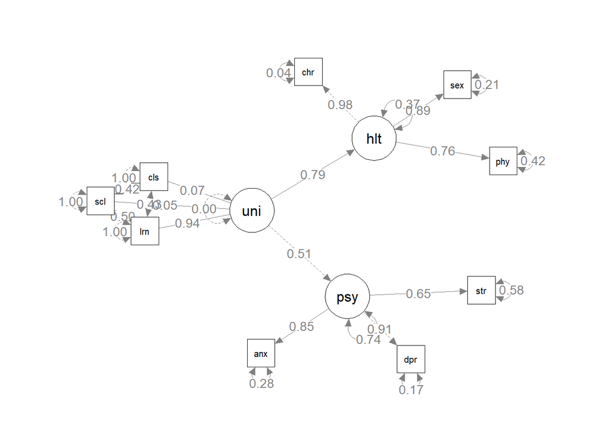

```r
semPlot::semPaths(model.fit, whatLabels = 'std', layout = "spring", edge.label.cex = 1)
```

QUESTION: Look at the solution of the final model and describe that model. Do all of the items load with their latent variable? Does university appear to predict psychological and health factors?